# Free_Text_Supervised_Learning_Example

## Supervised Learning with Free Text

This is a supervised learning/NLP example in python.

Goal: using women's clothing e-commerce reviews, predict whether the review recommends the item or not based on the text of the review.

Packages used in this example:

```python
import pandas as pd
import spacy as sp
nlp=sp.load('en_core_web_sm')
import nltk
from nltk.corpus import stopwords
import numpy as np
from lime import lime_text
import seaborn as sb
import shap
```

### Data Cleaning and Preprocessing

Our data comes from Kaggle: https://www.kaggle.com/datasets/nicapotato/womens-ecommerce-clothing-reviews

```python
raw = pd.read_csv(r'C:\Users\qtd7816\pythonian\data.csv')
```

```python
raw.head()
```

|  | Unnamed: 0 | Clothing ID | Age | Title | Review Text | Rating | Recommended IND | Positive Feedback Count | Division Name | Department Name | Class Name |
| --- | --- | --- | --- | --- | --- | --- | --- | --- | --- | --- | --- |
| 0 | 0 | 767 | 33 | NaN | Absolutely wonderful - silky and sexy and comf... | 4 | 1 | 0 | Initmates | Intimate | Intimates |
| 1 | 1 | 1080 | 34 | NaN | Love this dress! it's sooo pretty. i happene... | 5 | 1 | 4 | General | Dresses | Dresses |
| 2 | 2 | 1077 | 60 | Some major design flaws | I had such high hopes for this dress and reall... | 3 | 0 | 0 | General | Dresses | Dresses |
| 3 | 3 | 1049 | 50 | My favorite buy! | I love, love, love this jumpsuit. it's fun, fl... | 5 | 1 | 0 | General Petite | Bottoms | Pants |
| 4 | 4 | 847 | 47 | Flattering shirt | This shirt is very flattering to all due to th... | 5 | 1 | 6 | General | Tops | Blouses |

Dropping review title (too many missing), setting review text to string, and using listwise deletion to remove any additional missing data.

```python
df = raw \
.drop(['Title'],axis=1) \
.astype({'Review Text':'string'}) \
.dropna()

df.head()
```

|  | Unnamed: 0 | Clothing ID | Age | Review Text | Rating | Recommended IND | Positive Feedback Count | Division Name | Department Name | Class Name |
| --- | --- | --- | --- | --- | --- | --- | --- | --- | --- | --- |
| 0 | 0 | 767 | 33 | Absolutely wonderful - silky and sexy and comf... | 4 | 1 | 0 | Initmates | Intimate | Intimates |
| 1 | 1 | 1080 | 34 | Love this dress! it's sooo pretty. i happene... | 5 | 1 | 4 | General | Dresses | Dresses |
| 2 | 2 | 1077 | 60 | I had such high hopes for this dress and reall... | 3 | 0 | 0 | General | Dresses | Dresses |
| 3 | 3 | 1049 | 50 | I love, love, love this jumpsuit. it's fun, fl... | 5 | 1 | 0 | General Petite | Bottoms | Pants |
| 4 | 4 | 847 | 47 | This shirt is very flattering to all due to th... | 5 | 1 | 6 | General | Tops | Blouses |

Next, let's define a function to lemmatize our text and remove stopwords.

```python
def preprocessing(text):
  """
  Adapted from the 2022 SIOP NLP Workshop.
  Reads in text,
  converts to a spacy object,
  appends the lemmatized words,
  then returns the lower case text with lemmatized format where applicable and
  without stopwords.
  """
  lem_text = [] # create a list
  sp_text = nlp(text) # convert the input text to a format spacy can use
  for word in sp_text: # loop through the text, get the word.lemma_ and append it to the list
      lem_text.append(word.lemma_)
  return " ".join([word for word in lem_text if word.lower() not in stopwords.words('english')]) # join the list back together
```

Now let's get to preprocessing!

```python
df['cleaned_text'] = df['Review Text'].apply(preprocessing)

df.head()
```

|  | Unnamed: 0 | Clothing ID | Age | Review Text | Rating | Recommended IND | Positive Feedback Count | Division Name | Department Name | Class Name | cleaned_text |
| --- | --- | --- | --- | --- | --- | --- | --- | --- | --- | --- | --- |
| 0 | 0 | 767 | 33 | Absolutely wonderful - silky and sexy and comf... | 4 | 1 | 0 | Initmates | Intimate | Intimates | absolutely wonderful - silky sexy comfortable |
| 1 | 1 | 1080 | 34 | Love this dress! it's sooo pretty. i happene... | 5 | 1 | 4 | General | Dresses | Dresses | love dress ! sooo pretty . happen find sto... |
| 2 | 2 | 1077 | 60 | I had such high hopes for this dress and reall... | 3 | 0 | 0 | General | Dresses | Dresses | high hope dress really want work . initially o... |
| 3 | 3 | 1049 | 50 | I love, love, love this jumpsuit. it's fun, fl... | 5 | 1 | 0 | General Petite | Bottoms | Pants | love , love , love jumpsuit . fun , flirty , f... |
| 4 | 4 | 847 | 47 | This shirt is very flattering to all due to th... | 5 | 1 | 6 | General | Tops | Blouses | shirt flattering due adjustable front tie . pe... |

### Preparing for Modeling

An important note: our outcome of interest is quite imbalanced, which will likely affect our model accuracy.

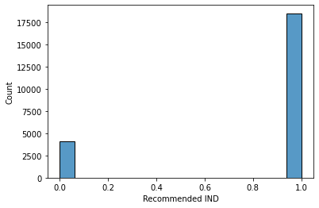

```python
sb.histplot(df['Recommended IND'])
```

Let's specify our n-gram range and prepare our term frequency-inverse document frequency for use in the model.

```python
from sklearn.model_selection import train_test_split
from sklearn.feature_extraction.text import TfidfVectorizer

# use an n-gram range of 1 & 2 and only keep tokens that appear in at least 7 responses

ngram_lower = 1
ngram_upper = 2
min_df = 7

vectorizer = TfidfVectorizer(min_df=min_df, ngram_range=(ngram_lower,ngram_upper))
```

Now we specify our predictor (the tf-idf preprocessed text) and outcome (recommending the item).

```python
X = vectorizer.fit_transform(df['cleaned_text'])
Y = df['Recommended IND']
```

### Model and Results

Starting with a logistic regression model at a 75/25 train/test split.

```python
X_train, X_test, Y_train, Y_test = train_test_split(X, Y, test_size=.25, random_state=101,stratify= Y)

from sklearn.linear_model import LogisticRegression

model = LogisticRegression().fit(X_train,Y_train)

print('Accuracy of logistic regression classifier on test set: {:.2f}'.format(model.score(X_test, Y_test)))
```

```
Accuracy of logistic regression classifier on test set: 0.89
```

Our accuracy is actually pretty good right off the bat but let's dig a little deeper.

```python
from sklearn.metrics import confusion_matrix
from sklearn.metrics import classification_report

predictions = model.predict(X_test)
matrix = confusion_matrix(Y_test,predictions)

print(matrix)
print(classification_report(Y_test, predictions))
```

```
[[ 483  542]
 [  96 4536]]
              precision    recall  f1-score   support

           0       0.83      0.47      0.60      1025
           1       0.89      0.98      0.93      4632

    accuracy                           0.89      5657
   macro avg       0.86      0.73      0.77      5657
weighted avg       0.88      0.89      0.87      5657
```

Our recall for "not recommended" is not great, meaning we're seeing a large number of false negatives. For this example, I will let it go but we could consider random over/under-sampling to correct this.

### Model Explainability

Let's learn more about how our model is making classification decisions. First we need a translator function to compare between the preprocessed tf-idf and the raw text.

```python
def pred_fn(text):
    text_transformed = vectorizer.transform(text)
    return model.predict_proba(text_transformed)

def pred_actual(text):
    text_transformed = vectorizer.transform(text)
    return model.predict(text_transformed)

#Two examples of how these functions work, both probability and rounded.

print(pred_fn([df.iloc[0,3]]))
print(pred_actual([df.iloc[0,3]]))
```

```
[[0.05862069 0.94137931]]
[1]
```

Let's start by identifying the most important words overall in determining classification.

[output not shown]

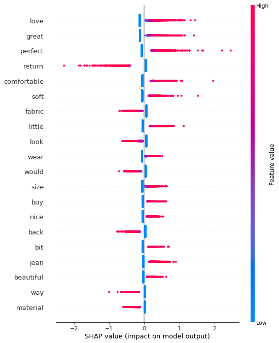

```python
shap_explainer = shap.LinearExplainer(model,X_train,feature_dependence = "independent")

shap_values = shap_explainer.shap_values(X_test)

X_test_array = X_test.toarray()

shap.summary_plot(shap_values,
                  X_test_array,
                  feature_names=vectorizer.get_feature_names())
```

Here are the top 20, some are more surprising than others. Now let's use LIME to look in-depth at a single review.

```python
explainer = lime_text.LimeTextExplainer(class_names = [0,1])

exp = explainer.explain_instance(df.iloc[0,3], classifier_fn = pred_fn) #using LIME to explain our first row.

print("Actual Text : ", df.iloc[0,3])
print("Prediction : ", pred_actual([df.iloc[0,3]]))
print("Actual :     ", df.iloc[0,5])

exp.show_in_notebook()
```

[output not shown]

```
Actual Text :  Absolutely wonderful - silky and sexy and comfortable
Prediction :  [1]
Actual :      1
```